# Progress Memo 1

Final Project  
Data Science 2 with R (STAT 301-2)

Author

Meera Trivedi

**Github Repo Link**

[My GitHub Repo](https://github.com/stat301-2-2024-winter/final-project-2-meeratrivedi.git)

## Prediction Problem

My prediction problem is going to be to use various types of data on real estate properties, ranging from data on the actual construction of the building to the environment around it, to predict the overall quality of living of the people living in those properties. Currently quality of living is a numerical variable corresponding to an index but because of this I could change it to a factor variable with different ordered levels as ranges of values (example: 0-10, 10-20, 20-30, etc.) Once it is a factor variable this will be a classification problem. The data I found happens to be from Slovakia which is interesting because I don’t ever see that country represented in the media so it would be nice to learn a little more about it. The main reason I chose this data though is because I am a sophomore moving off campus next year so I have looked into apartments both by myself and with friends and finally signed my own lease. In the process I had to evaluate data on each building to decide what would be the best option for me. I also used to watch house flipping and renovating shows with my dad when I was younger all the time so I thought it might be fun to look into what would make a property successful, and a way to measure that is quality of living. I think it’s very useful to uncover relationships between the quality of living and every available aspect of a building because in order for a building to be marketable people have to gain some benefit from living there. A model to predict something as useful as quality of living would be helpful to understand the value of a building based on its various metrics and categorical data.

## Data source

My data is called “Real Estate Dataset”[^1] and has been downloaded from Kaggle, on which it is described as a dataset that explores “spatial dynamics, price, and quality of apartments in Slovakia”. The data comes from scraping advertising data from the nehnutelnosti.sk website as of November 2023, so this is fairly recent data, and only pertains to apartment listings. The Nehnutelnosti website has real estate listings and provides services to help find available properties in Slovakia. Each observation refers to an apartment listing and the variables measured about each listing range from costs, to dimensions, to features, to the safety and environment around the apartment’s building. It was posted to Kaggle by Arnold Kakas, who notes that he has intentionally left the dataset completely raw for the purpose of people using it to learn data cleaning, data visualization, and training predictive models, which is the purpose of this project.

<sup>1</sup> Kakas, Arnold. (2023, Nov.). *Real Estate Dataset*. Kaggle. — https://www.kaggle.com/datasets/arnoldkakas/real-estate-dataset/data

## Data quality & complexity check

### Data

```r
realestate <- read_delim(here("data/raw/Real_Estate_Dataset.csv"),
                         delim = ";",
                         escape_double = FALSE,
                         trim_ws = TRUE) |>
  clean_names()
```

### Skim

Data summary

| Name | realestate |
| --- | --- |
| Number of rows | 15403 |
| Number of columns | 27 |
| _______________________ |  |
| Column type frequency: |  |
| character | 7 |
| numeric | 20 |
| ________________________ |  |
| Group variables | None |

**Variable type: character**

| skim_variable | n_missing | complete_rate | min | max | empty | n_unique | whitespace |
| --- | --- | --- | --- | --- | --- | --- | --- |
| name_nsi | 0 | 1.00 | 3 | 46 | 0 | 598 | 0 |
| condition | 327 | 0.98 | 12 | 23 | 0 | 6 | 0 |
| certificate | 8958 | 0.42 | 1 | 4 | 0 | 8 | 0 |
| construction_type | 13036 | 0.15 | 4 | 26 | 0 | 11 | 0 |
| orientation | 14380 | 0.07 | 4 | 9 | 0 | 8 | 0 |
| type | 0 | 1.00 | 6 | 24 | 0 | 7 | 0 |
| district | 0 | 1.00 | 4 | 20 | 0 | 79 | 0 |

**Variable type: numeric**

| skim_variable | n_missing | complete_rate | mean | sd | p0 | p25 | p50 | p75 | p100 |
| --- | --- | --- | --- | --- | --- | --- | --- | --- | --- |
| price | 0 | 1.00 | 165205.67 | 162973.63 | 11500 | 99900 | 136900 | 190000 | 9936000 |
| index | 10241 | 0.34 | 70.79 | 22.87 | 4 | 69 | 78 | 84 | 95 |
| environment | 11271 | 0.27 | 70.03 | 24.45 | 4 | 69 | 77 | 84 | 99 |
| quality_of_living | 11271 | 0.27 | 77.31 | 28.12 | 4 | 77 | 88 | 94 | 99 |
| safety | 11271 | 0.27 | 56.18 | 34.50 | 2 | 10 | 69 | 87 | 98 |
| transport | 11271 | 0.27 | 65.52 | 32.72 | 2 | 48 | 79 | 91 | 98 |
| services | 11271 | 0.27 | 73.55 | 24.98 | 2 | 66 | 82 | 92 | 99 |
| relax | 11271 | 0.27 | 51.62 | 23.00 | 2 | 38 | 54 | 69 | 95 |
| area | 716 | 0.95 | 1523.09 | 3946.18 | 1 | 57 | 74 | 615 | 209900 |
| energy_costs | 14423 | 0.06 | 150.62 | 52.32 | 20 | 110 | 150 | 190 | 365 |
| provision | 0 | 1.00 | 0.16 | 0.36 | 0 | 0 | 0 | 0 | 1 |
| year_built | 11525 | 0.25 | 1901.70 | 499.06 | 1 | 1971 | 1980 | 2020 | 19741 |
| last_reconstruction | 14721 | 0.04 | 2018.30 | 6.01 | 1968 | 2016 | 2020 | 2023 | 2024 |
| total_floors | 8117 | 0.47 | 5.61 | 3.66 | 1 | 3 | 5 | 8 | 46 |
| floor | 7087 | 0.54 | 3.49 | 2.63 | -7 | 2 | 3 | 5 | 34 |
| lift | 0 | 1.00 | 0.27 | 0.44 | 0 | 0 | 0 | 1 | 1 |
| balkonies | 13636 | 0.11 | 1.11 | 0.39 | 1 | 1 | 1 | 1 | 6 |
| loggia | 13883 | 0.10 | 1.11 | 0.36 | 1 | 1 | 1 | 1 | 5 |
| cellar | 0 | 1.00 | 0.01 | 0.12 | 0 | 0 | 0 | 0 | 1 |
| rooms | 0 | 1.00 | 2.48 | 0.89 | 1 | 2 | 3 | 3 | 5 |

### Missingness

Unfortunately there are a lot of missing values of most of the variables in this dataset as shown above and below. 19 out of the 27 variables have values missing and most of those 19 have missing values for more than half of the dataset. Fortunately since the dataset is so large, subsetting the data set to filter out missing values still leaves thousands of observations to analyze; however not as many as would be ideal.

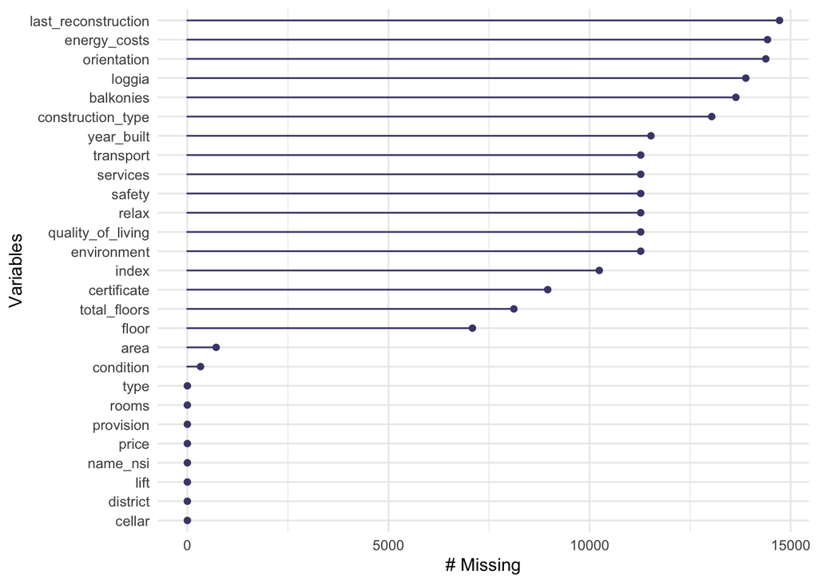

Since I am using `quality_of_living` as my target variable, I made a subset of the data that filters out observations that have missing values of that variable and found that the result was 4132 observations. This is over 3000 but not close to 15000 like the raw dataset is. There are a lot more variables that do not have missing values in this subset which will be helpful going forward.

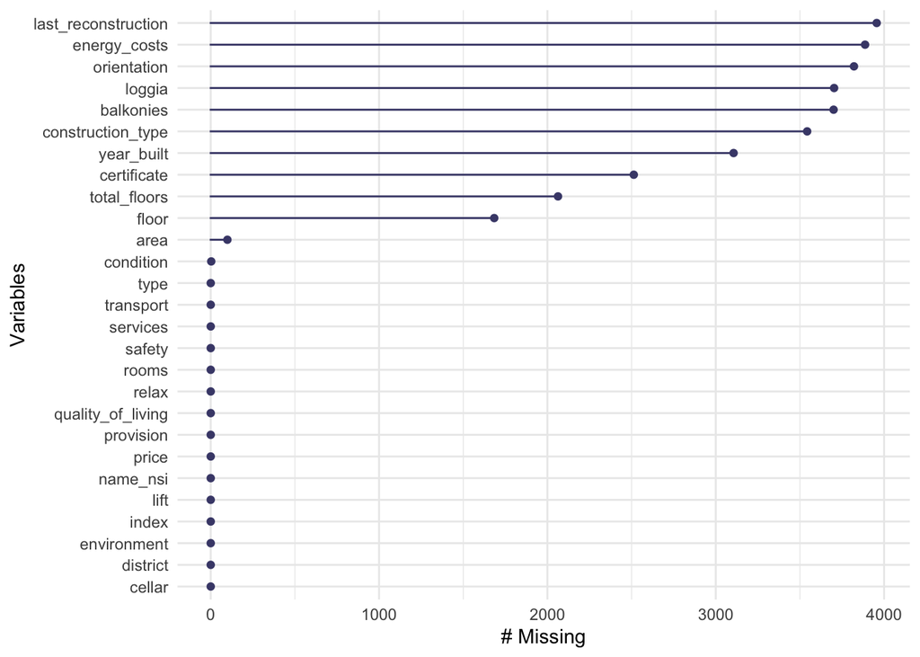

## Target Variable Analysis

This is a density plot of the ratings of the quality of living of each apartment listing. As you can see, there are two peaks in this plot where the density is the highest, meaning that there are more apartments with rankings a little lower than 12 than 25-50 but most of the ranked apartments have rankings above 75. This is a good thing for the people who want to live in those apartments but from an analysis perspective it is very skewed and will need to be transformed.

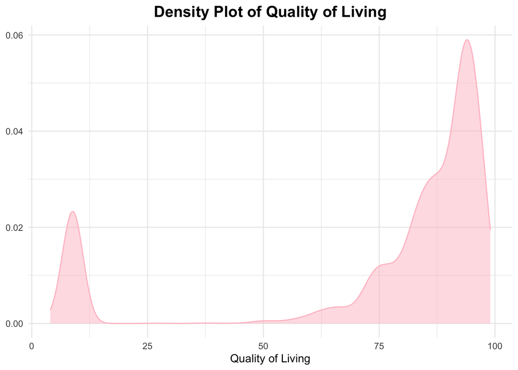

I attempted a log transformation and a log10 transformation but neither really pushed the skew towards a more normal distribution, so I’ll need to see what else is possible. Perhaps I can split the subset in half (from 0-50 and 50-100) to transform each peak separately and maybe analyze separately. Shown here is the log10 transformation, and the log transformation looked almost exactly the same:

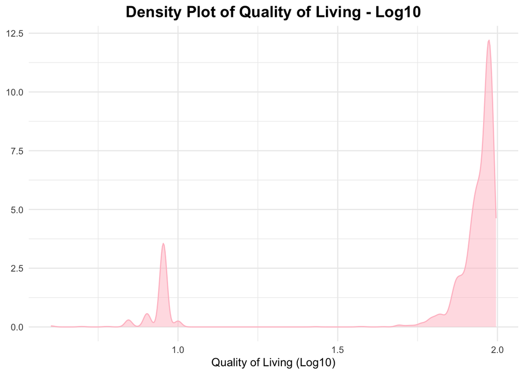

I also decided to explore this variable as if it were a factor because I will probably continue with it as a factor to make this a classification problem. Since each value of this variable is a number on an index from 0-100, each number represents a level of quality of living so I thought it made sense that it should be categorical. This is what the distribution of it as a factor looks like:

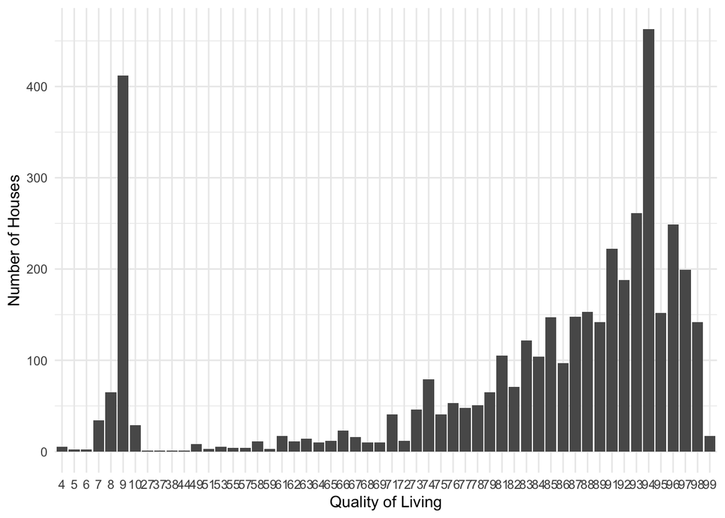

This is helpful to understand the skew in the same way that the density plot shows, but these labels are incredibly difficult to read because of the wide range of values for this variable. So, I made another barplot with specified levels with ranges of these values to see the distribution easier. Each range of values is not the same numerically though because of the very reduced amount of values from 10-40.

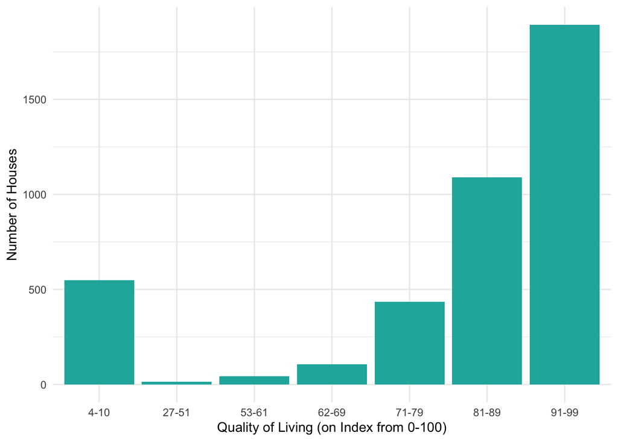

## Potential data issues/Misc

The only issue I can think of right now is the missingness. I definitely want to create subsets of the data to use for analysis and get everything cleaned and finalized before the next progress memo is announced so I am ready to start modeling as soon as possible since I have many predictor variables I could use.